# Introduction to the Syuzhet Package

Matthew Jockers

2021-04-12

# Introduction

This vignette demonstrates use of the basic functions of the Syuzhet package. The package comes with four sentiment dictionaries and provides a method for accessing the robust, but computationally expensive, sentiment extraction tool developed in the NLP group at Stanford. Use of this later method requires that you have already installed the coreNLP package (see http://nlp.stanford.edu/software/corenlp.shtml).

The goal of this vignette is to introduce the main functions in the package so that you can quickly extract plot and sentiment data from your own text files. This document will use a short example passage to demonstrate the functions and the various ways that the extracted data can be returned and or visualized.

## get_sentences

After loading the package (`library(syuzhet)`), you begin by parsing a text into a vector of sentences. For this you will utilize the `get_sentences()` function which implements the `openNLP` sentence tokenizer. The `get_sentences()` function includes an argument that determines how to handle quoted text. By default, quotes are stripped out before sentence parsing. (Thanks to Annie Swafford who observed that sentence parsing with openNLP improves when quotations are removed.) In the example that follows, a very simple text passage containing twelve sentences is loaded directly. (You could just as easily load a text file from your local hard drive or from a URL using the `get_text_as_string()` function. `get_text_as_string()` is described below.)

```r
library(syuzhet)
my_example_text <- "I begin this story with a neutral statement.
  Basically this is a very silly test.
  You are testing the Syuzhet package using short, inane sentences.
  I am actually very happy today.
  I have finally finished writing this package.
  Tomorrow I will be very sad.
  I won't have anything left to do.
  I might get angry and decide to do something horrible.
  I might destroy the entire package and start from scratch.
  Then again, I might find it satisfying to have completed my first R package.
  Honestly this use of the Fourier transformation is really quite elegant.
  You might even say it's beautiful!"
s_v <- get_sentences(my_example_text)
```

The result of calling `get_sentences()` in this example is a new character vector named `s_v`. This vector contains 12 items, one for each tokenized sentence. If you wish to examine the sentences, you can inspect the resultant character vector as you would any other character vector in R. For example,

```r
class(s_v)
```

```
## [1] "character"
```

```r
str(s_v)
```

```
##  chr [1:12] "I begin this story with a neutral statement." ...
```

```r
head(s_v)
```

```
## [1] "I begin this story with a neutral statement."
## [2] "Basically this is a very silly test."
## [3] "You are testing the Syuzhet package using short, inane sentences."
## [4] "I am actually very happy today."
## [5] "I have finally finished writing this package."
## [6] "Tomorrow I will be very sad."
```

## get_tokens

The `get_tokens` function allows you to tokenize by words instead of sentences. You can enter a custom regular expression for defining word boundaries. By default, the function uses the “\W” regex to identify word boundaries. Note that “\W” does not remove underscores.

```r
poa_word_v <- get_tokens(joyces_portrait, pattern = "\\W")
```

## get_sentiment()

After you have collected the sentences or word tokens from a text into a vector, you will send them to the `get_sentiment` function which will asses the sentiment of each word or sentence. This function takes two arguments: a character vector (of sentences or words) and a “method.” The method you select determines which of the four available sentiment extraction methods to employ. In the example that follows below, the “syuzhet” (default) method is called.

Other methods include “bing”, “afinn”, “nrc”, and “stanford”. The documentation for the function provides bibliographic citations for the dictionaries. To see the documentation, simply enter `?get_sentiment` into your console.

```r
syuzhet_vector <- get_sentiment(poa_v, method="syuzhet")
# OR if using the word token vector from above
# syuzhet_vector <- get_sentiment(poa_word_v, method="syuzhet")
```

```r
head(syuzhet_vector)
```

```
## [1]  2.50  0.60  0.00 -0.25  0.00  0.00
```

Notice, however, that the different methods will return slightly different results. Part of the reason for this is that each method uses a slightly different scale.

```r
bing_vector <- get_sentiment(poa_v, method = "bing")
head(bing_vector)
```

```
## [1]  1  0 -1 -1  0  0
```

```r
afinn_vector <- get_sentiment(poa_v, method = "afinn")
head(afinn_vector)
```

```
## [1] 3 0 0 1 0 0
```

```r
nrc_vector <- get_sentiment(poa_v, method = "nrc", lang = "english")
head(nrc_vector)
```

```
## [1]  1  1 -1  0  0  0
```

```r
# Stanford Example: Requires installation of coreNLP and path to directory
# tagger_path <- "/Applications/stanford-corenlp-full-2014-01-04"
# stanford_vector <- get_sentiment(poa_v, method="stanford", tagger_path)
# head(stanford_vector)
```

Because the different methods use different scales, it may be more useful to compare them using R’s built in `sign` function. The `sign` function converts all positive number to `1`, all negative numbers to `-1` and all zeros remain `0`.

```r
rbind(
  sign(head(syuzhet_vector)),
  sign(head(bing_vector)),
  sign(head(afinn_vector)),
  sign(head(nrc_vector))
)
```

```
##      [,1] [,2] [,3] [,4] [,5] [,6]
## [1,]    1    1    0   -1    0    0
## [2,]    1    0   -1   -1    0    0
## [3,]    1    0    0    1    0    0
## [4,]    1    1   -1    0    0    0
```

Once the sentiment values are determined, we might, for example, wish to sum the values in order to get a measure of the overall emotional valence in the text:

```r
sum(syuzhet_vector)
```

```
## [1] -209.2
```

The result, -209.2 is negative, a fact that may indicate that overall, the text is kind of a bummer. As an alternative, we may wish to understand the central tendency, the mean emotional valence.

```r
mean(syuzhet_vector)
```

```
## [1] -0.03911743
```

This mean of -0.0391174 is slightly below zero. This and similar summary statistics may offer a better sense of how the emotions in the passage are distributed. You might use the summary function to get a broad sense of the distribution of sentiment in the text.

```r
summary(syuzhet_vector)
```

```
##     Min.  1st Qu.   Median     Mean  3rd Qu.     Max.
## -8.65000 -0.45000  0.00000 -0.03912  0.50000  6.60000
```

While these global measures of sentiment can be informative, they tell us very little in terms of how the narrative is structured and how these positive and negative sentiments are activated across the text. You may, therefore, find it useful to plot the values in a graph where the x-axis represents the passage of time from the beginning to the end of the text, and the y-axis measures the degrees of positive and negative sentiment. Here is an example using the very simple example text from above:

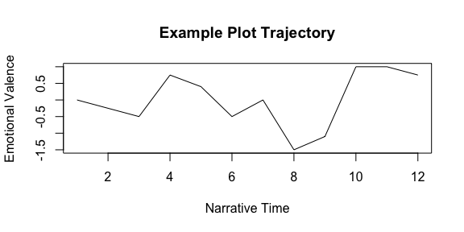

```r
my_example_text <- "I begin this story with a neutral statement.
  Basically this is a very silly test.
  You are testing the Syuzhet package using short, inane sentences.
  I am actually very happy today.
  I have finally finished writing this package.
  Tomorrow I will be very sad.
  I won't have anything left to do.
  I might get angry and decide to do something horrible.
  I might destroy the entire package and start from scratch.
  Then again, I might find it satisfying to have completed my first R package.
  Honestly this use of the Fourier transformation is really quite elegant.
  You might even say it's beautiful!"
s_v <- get_sentences(my_example_text)
s_v_sentiment <- get_sentiment(s_v)
plot(
  s_v_sentiment,
  type="l",
  main="Example Plot Trajectory",
  xlab = "Narrative Time",
  ylab= "Emotional Valence"
  )
```

What is observed here is useful for demonstration purposes but is hardly typical of what is seen in a 300 page novel. Over the course of three- or four-hundred pages, one will encounter quite a lot of affectual noise. Here, for example, is a plot of Joyce’s *Portrait of the Artist as a Young man*.

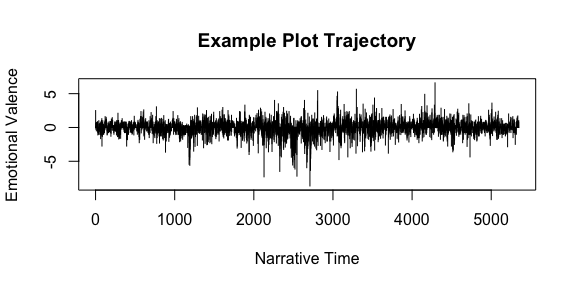

```r
plot(
  syuzhet_vector,
  type="h",
  main="Example Plot Trajectory",
  xlab = "Narrative Time",
  ylab= "Emotional Valence"
  )
```

While this raw data may be useful for certain applications, for visualization it is generally preferable to remove the noise and reveal the simple shape of the trajectory. One way to do that would be to apply a trend line. The next plot applies a moving average trend line to the simple example text containing twelve sentences.

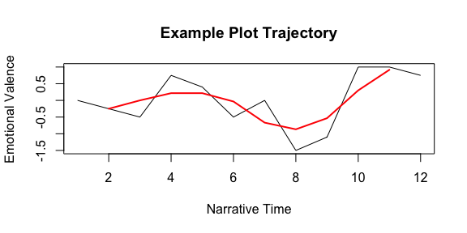

While a moving average can be useful, we must remember that data on the edges is lost. Nevertheless, such smoothing can be useful for getting a sense of the emotional trajectory of a single text.

## get_percentage_values

When it comes to comparing the shape of one trajectory to another, the `get_percentage_values` function can be useful. The `get_percentage_values` function divides a text into an equal number of “chunks” and then calculates the mean sentiment valence for each. In the example below, the sentiments from *Portrait* are binned into 10 chunks and then plotted.

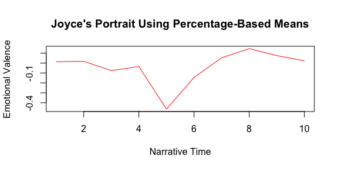

```r
percent_vals <- get_percentage_values(syuzhet_vector, bins = 10)
plot(
  percent_vals,
  type="l",
  main="Joyce's Portrait Using Percentage-Based Means",
  xlab = "Narrative Time",
  ylab= "Emotional Valence",
  col="red"
  )
```

Using the optional `bins` argument, you can control how many sentences are included inside each percentage based chunk:

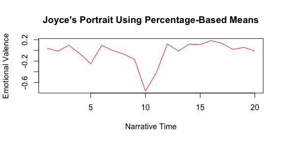

```r
percent_vals <- get_percentage_values(syuzhet_vector, bins = 20)
plot(
  percent_vals,
  type="l",
  main="Joyce's Portrait Using Percentage-Based Means",
  xlab = "Narrative Time",
  ylab= "Emotional Valence",
  col="red"
  )
```

Unfortunately, when a series of sentence values are combined into a larger chunk using a percentage based measure, extremes of emotional valence tend to get watered down. This is especially true when the segments of text that percentage based chunking returns are especially large. When averaged, a passage of 1000 sentences is far more likely to contain a wide range of values than a 100 sentence passage. Indeed, the means of longer passages tend to converge toward 0. But this is not the only problem with percentage-based normalization. In addition to dulling the emotional variance, percentage-based normalization makes book to book comparison somewhat futile. A comparison of the first tenth of a very long book, such as Melville’s *Moby Dick* with the first tenth of a short novella such as Oscar Wilde’s *Picture of Dorian Grey* is simply not all that fruitful because in one case the first tenth is composed of 1000 sentences and in the other just 100.

The `Syuzhet` package provides two alternatives to percentage-based comparison using either the Fourier or Discrete Cosine Transformations in combination with a low pass filter.

## get_transformed_values

NOTE: `get_transformed_values` is maintained for legacy purposes. Users should consider using `get_dct_transform()` instead.

Shape smoothing and normalization using a Fourier based transformation and low pass filtering is achieved using the `get_transformed_values` function as shown below. The various arguments are described in the help documentation.

```r
library(syuzhet)
ft_values <- get_transformed_values(
      syuzhet_vector,
      low_pass_size = 3,
      x_reverse_len = 100,
      padding_factor = 2,
      scale_vals = TRUE,
      scale_range = FALSE
      )
```

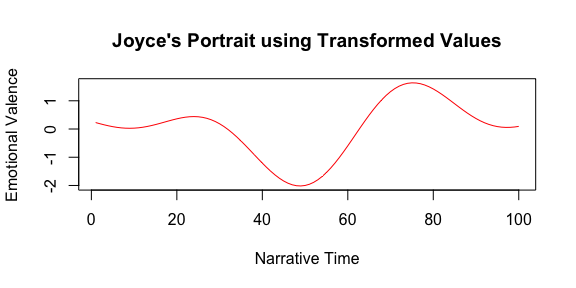

```r
plot(
  ft_values,
  type ="l",
  main ="Joyce's Portrait using Transformed Values",
  xlab = "Narrative Time",
  ylab = "Emotional Valence",
  col = "red"
  )
```

## get_dct_transform

The `get_dct_transform` is similar to `get_transformed_values` function, but it applies the simpler discrete cosine transformation (DCT) in place of the fast Fourier transform. It’s main advantage is in its better representation of edge values in the smoothed version of the sentiment vector.

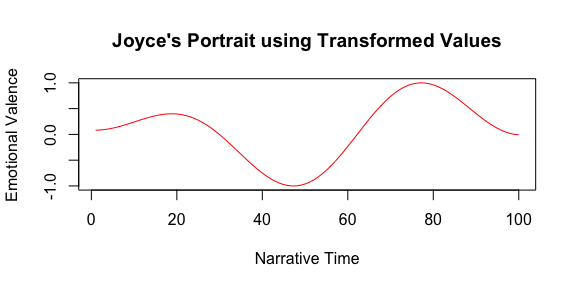

```r
library(syuzhet)
dct_values <- get_dct_transform(
      syuzhet_vector,
      low_pass_size = 5,
      x_reverse_len = 100,
      scale_vals = F,
      scale_range = T
      )
plot(
  dct_values,
  type ="l",
  main ="Joyce's Portrait using Transformed Values",
  xlab = "Narrative Time",
  ylab = "Emotional Valence",
  col = "red"
  )
```

##simple_plot The `simple_plot` function takes a sentiment vector and applies three smoothing methods. The smoothers include a moving average, loess, and discrete cosine transformation. This function produces two plots stacked. The first shows all three smoothing methods on the same graph. The second graph shows only the DCT smoothed line, but does so on a normalized time axis. The shape of the DCT line in both the top and bottom graphs are identical. In the following code Flaubert’s *Madame Bovary* has been used in place of Joyce’s *Portrait*.

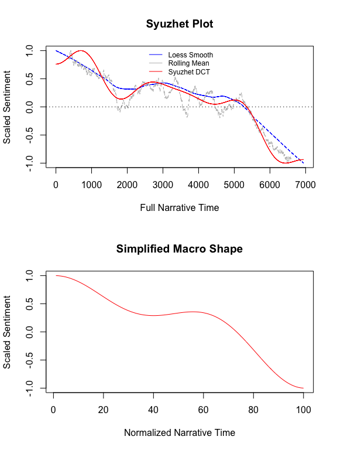

```r
path_to_a_text_file <- system.file("extdata", "bovary.txt", package = "syuzhet")
bovary <- get_text_as_string(path_to_a_text_file)
bovary_v <- get_sentences(bovary)
bovary_sentiment <- get_sentiment(bovary_v)
simple_plot(bovary_sentiment)
```

## get_nrc_sentiment

The `get_nrc_sentiment` implements Saif Mohammad’s NRC Emotion lexicon. According to Mohammad, “the NRC emotion lexicon is a list of words and their associations with eight emotions (anger, fear, anticipation, trust, surprise, sadness, joy, and disgust) and two sentiments (negative and positive)” (See http://saifmohammad.com/WebPages/NRC-Emotion-Lexicon.htm). The `get_nrc_sentiment` function returns a data frame in which each row represents a sentence from the original file. The columns include one for each emotion type was well as the positive or negative sentiment valence. The example below calls the function using the simple twelve sentence example passage stored in the `s_v` object from above.

```r
nrc_data <- get_nrc_sentiment(s_v)
```

One the data has been returned, it can be accessed as you would any other data frame. The data in the columns (anger, anticipation, disgust, fear, joy, sadness, surprise, trust, negative, positive) can be accessed individually or in sets. Here we identify the item(s) with the most “anger” and use it as a reference to find the corresponding sentence from the passage.

```r
angry_items <- which(nrc_data$anger > 0)
s_v[angry_items]
```

```
## [1] "I might get angry and decide to do something horrible."
```

Likewise, it is easy to identify items that the NRC lexicon identified as joyful:

```r
joy_items <- which(nrc_data$joy > 0)
s_v[joy_items]
```

```
## [1] "Basically this is a very silly test."
## [2] "I am actually very happy today."
## [3] "I have finally finished writing this package."
## [4] "Honestly this use of the Fourier transformation is really quite elegant."
## [5] "You might even say it's beautiful!"
```

It is simple to view all of the emotions and their values:

```r
pander::pandoc.table(nrc_data[, 1:8], split.table = Inf)
```

| anger | anticipation | disgust | fear | joy | sadness | surprise | trust |
| --- | --- | --- | --- | --- | --- | --- | --- |
| 0 | 1 | 0 | 0 | 0 | 0 | 0 | 2 |
| 0 | 0 | 0 | 0 | 1 | 0 | 0 | 0 |
| 0 | 0 | 0 | 0 | 0 | 0 | 0 | 0 |
| 0 | 1 | 0 | 0 | 1 | 0 | 0 | 1 |
| 0 | 1 | 1 | 0 | 1 | 0 | 1 | 1 |
| 0 | 1 | 0 | 0 | 0 | 0 | 0 | 0 |
| 0 | 0 | 0 | 0 | 0 | 0 | 0 | 0 |
| 2 | 0 | 2 | 1 | 0 | 0 | 0 | 0 |
| 0 | 1 | 0 | 0 | 0 | 0 | 0 | 0 |
| 0 | 0 | 0 | 0 | 0 | 0 | 0 | 0 |
| 0 | 0 | 0 | 0 | 1 | 0 | 0 | 0 |
| 0 | 0 | 0 | 0 | 1 | 0 | 0 | 0 |

Or you can examine only the positive and negative valence:

```r
pander::pandoc.table(nrc_data[, 9:10])
```

| negative | positive |
| --- | --- |
| 0 | 1 |
| 1 | 0 |
| 1 | 0 |
| 0 | 1 |
| 0 | 1 |
| 0 | 0 |
| 0 | 0 |
| 2 | 0 |
| 0 | 0 |
| 0 | 0 |
| 0 | 1 |
| 0 | 1 |

These last two columns are the ones used by the `nrc` method in the `get_sentiment` function discussed above. To calculate a single value of positive or negative valence for each sentence, the values in the negative column are converted to negative numbers and then added to the values in the positive column, like this.

```r
valence <- (nrc_data[, 9]*-1) + nrc_data[, 10]
valence
```

```
##  [1]  1 -1 -1  1  1  0  0 -2  0  0  1  1
```

Finally, the percentage of each emotion in the text can be plotted as a bar graph:

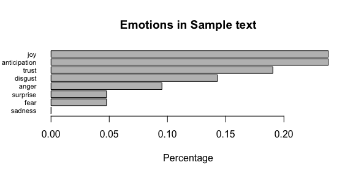

```r
barplot(
  sort(colSums(prop.table(nrc_data[, 1:8]))),
  horiz = TRUE,
  cex.names = 0.7,
  las = 1,
  main = "Emotions in Sample text", xlab="Percentage"
  )
```

## rescale_x_2

The `rescale_x_2` function is handy for re-scaling values to a normalized x and y axis. This is useful for comparing two sentiment arcs. Assume that we want to compare the shapes produced by applying a moving average to two different sentiment arcs. First we’ll compute the raw sentiment values in *Portrait of the Artist* and *Madame Bovary*.

```r
path_to_a_text_file <- system.file("extdata", "portrait.txt",package = "syuzhet")
joyces_portrait <- get_text_as_string(path_to_a_text_file)
poa_v <- get_sentences(joyces_portrait)
poa_values <- get_sentiment(poa_v, method="syuzhet")

path_to_a_text_file <- system.file("extdata", "bovary.txt", package = "syuzhet")
bovary <- get_text_as_string(path_to_a_text_file)
bovary_v <- get_sentences(bovary)
bovary_values <- get_sentiment(bovary_v)
```

Now we’ll calculate a moving average for each vector of raw values. We’ll use a window size equal to 1/10 of the overall length of the vector.

```r
pwdw <- round(length(poa_values)*.1)
poa_rolled <- zoo::rollmean(poa_values, k=pwdw)
bwdw <- round(length(bovary_values)*.1)
bov_rolled <- zoo::rollmean(bovary_values, k=bwdw)
```

The resulting vectors are of different lengths: 4814 and 6248, so we can use `rescale_x_2` to put them on the same scale.

```r
poa_list <- rescale_x_2(poa_rolled)
bov_list <- rescale_x_2(bov_rolled)
```

We can then plot the two lines on the same graph even though they are of different lengths:

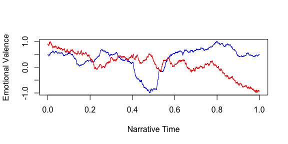

```r
plot(poa_list$x,
     poa_list$z,
     type="l",
     col="blue",
     xlab="Narrative Time",
     ylab="Emotional Valence")
lines(bov_list$x, bov_list$z, col="red")
```

Though we have now managed to scale both the x axis and y axis so as to be able to plot them on the same graph, we still don’t have vectors of the same length, which means that they cannot be easily compared mathematically. The time axis for *Portrait of the Artist* is 4814 units long and the time axis for *Madame Bovary* is 6248 units.

It is possible to sample from these vectors. In the code that follows here, we divide each vector into 100 samples and then plot those sampled points. The result is that each line is constructed out of 100 points on the x-axis.

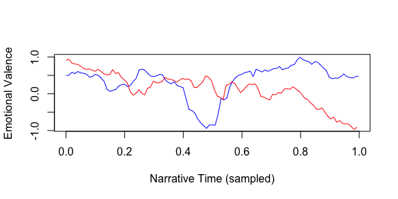

```r
poa_sample <- seq(1, length(poa_list$x), by=round(length(poa_list$x)/100))
bov_sample <- seq(1, length(bov_list$x), by=round(length(bov_list$x)/100))

plot(poa_list$x[poa_sample],
     poa_list$z[poa_sample],
     type="l",
     col="blue",
     xlab="Narrative Time (sampled)",
     ylab="Emotional Valence"
     )
lines(bov_list$x[bov_sample], bov_list$z[bov_sample], col="red")
```

With a equal number of values, in each vector, we can then apply a measure of distance or similarity, such as Euclidean distance of Pearson’s Correlation.

```r
# Euclidean
dist(rbind(poa_list$z[poa_sample], bov_list$z[bov_sample]))
```

```
##          1
## 2 7.223739
```

```r
# Correlation
cor(cbind(poa_list$z[poa_sample], bov_list$z[bov_sample]))
```

```
##            [,1]       [,2]
## [1,]  1.0000000 -0.2100283
## [2,] -0.2100283  1.0000000
```

Some users may find this sort of normalization and sampling preferable to the alternative method provided by the `get_dct_transform`, which assumes that the main flow of the sentiment trajectory is found within the low frequency components of the transformed signal. In this example, we have sampled from a set of values that have been smoothed using a moving average (which is a type of low pass filter). Once could easily apply this same routine to values that have been smoothed using some other method, such as the loess smoother that is implemented in the `simple_plot` function.

Here is how one might use a similar approach to sample from a loess smoothed line.

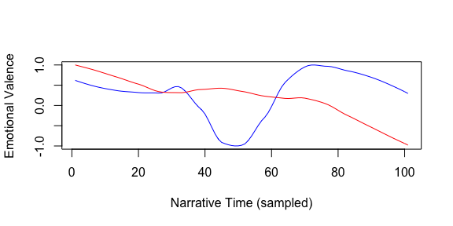

```r
poa_x <- 1:length(poa_values)
poa_y <- poa_values
raw_poa <- loess(poa_y ~ poa_x, span=.5)
poa_line <- rescale(predict(raw_poa))
bov_x <- 1:length(bovary_values)
bov_y <- bovary_values
raw_bov <- loess(bov_y ~ bov_x, span=.5)
bov_line <- rescale(predict(raw_bov))
poa_sample <- seq(1, length(poa_line), by=round(length(poa_line)/100))
bov_sample <- seq(1, length(bov_line), by=round(length(bov_line)/100))
plot(poa_line[poa_sample],
     type="l",
     col="blue",
     xlab="Narrative Time (sampled)",
     ylab="Emotional Valence"
     )
lines(bov_line[bov_sample], col="red")
```

## Multilingual Sentiment Lexicons

In version 1.0.4, support for sentiment detection in several languages was added by using the expanded NRC lexicon from Saif Mohammed. The lexicon includes sentiment values for 13,901 words in each of the following languages:

Arabic, Basque, Bengali, Catalan, Chinese_simplified, Chinese_traditional, Danish, Dutch, English, Esperanto, Finnish, French, German, Greek, Gujarati, Hebrew, Hindi, Irish, Italian, Japanese, Latin, Marathi, Persian, Portuguese, Romanian, Russian, Somali, Spanish, Sudanese, Swahili, Swedish, Tamil, Telugu, Thai, Turkish, Ukranian, Urdu, Vietnamese, Welsh, Yiddish, Zulu.

At the time of this release, Syuzhet will only work with languages that use Latin character sets. This effectively means that “Arabic”, “Bengali”, “Chinese_simplified”, “Chinese_traditional”, “Greek”, “Gujarati”, “Hebrew”, “Hindi”, “Japanese”, “Marathi”, “Persian”, “Russian”, “Tamil”, “Telugu”, “Thai”, “Ukranian”, “Urdu”, “Yiddish” are not supported even though these languages are part of the extended NRC dictionary.

It is also important to note that the sentence tokenizer inside the get_sentences() function is inherently biased for English syntax. Care should be taken to insure that the language being used is parsed properly by the get_sentences() function. It may be advisable to skip sentence tokenization in favor of word based tokenization using the get_tokens() function. Below is an example of how to call the Spanish lexicon to detect sentiment in *Don Quixote*.

```r
path_to_a_text_file <- system.file("extdata", "quijote.txt",package = "syuzhet")
my_text <- get_text_as_string(path_to_a_text_file)
char_v <- get_sentences(my_text)
method <- "nrc"
lang <- "spanish"
my_text_values <- get_sentiment(char_v, method=method, language=lang)
my_text_values[1:10]
```

```
##  [1]  0 -4  0  3  2  2 -1  2  1  6
```

## Custom Sentiment Lexicons

In Version 1.0.4, functionality to allow uses to load their own custom sentiment lexicons was added to the get_sentiments() function. To work, users need to create their custom lexicon as a data frame with at least two columns named “word” and “value.” Here is a simplified example:

```r
my_text <- "I love when I see something beautiful.  I hate it when ugly feelings creep into my head."
char_v <- get_sentences(my_text)
method <- "custom"
custom_lexicon <- data.frame(word=c("love", "hate", "beautiful", "ugly"), value=c(1,-1,1, -1))
my_custom_values <- get_sentiment(char_v, method = method, lexicon = custom_lexicon)
my_custom_values
```

```
## [1]  2 -2
```

## Parallelization

Collecting sentiment results on large volumes of data can be time consuming. One could call `get_sentiment` and provide cluster information from `parallel::makeCluster()` to achieve results quicker on systems with multiple cores. For example, on *Madame Bovary* as above:

```r
require(parallel)
cl <- makeCluster(2) # or detect_cores() - 1
clusterExport(cl = cl, c("get_sentiment", "get_sent_values", "get_nrc_sentiment", "get_nrc_values", "parLapply"))
bovary_sentiment_par <- get_sentiment(bovary_v, cl=cl)
bovary_nrc_par <- get_sentiment(bovary_v, method='nrc', cl=cl)
stopCluster(cl)
```

## Mixed Messages

Sometimes we might want to identify areas of a text where there is emotional ambiguity. The `mixed_messages()` function offers one way of identifying sentences that seem to have contradicting language. This function calculates the “emotional entropy” of a string based on the amount of conflicting valence found in the sentence’s words. Emotional entropy can be thought of as a measure of unpredictability and surprise based on the consistency or inconsistency of the emotional language in a given string. A string with conflicting emotional language may be said to express or contain a “mixed message.” Here is an example that attempts to identify and plot ares in *Madame Bovary* that have the highest and lowest concentration of mixed messages.

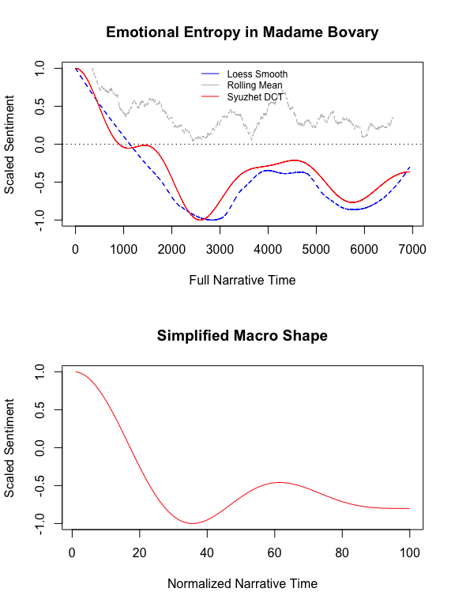

```r
path_to_a_text_file <- system.file("extdata", "bovary.txt", package = "syuzhet")
sample <- get_text_as_string(path_to_a_text_file)
sample_sents <- get_sentences(sample)
test <- lapply(sample_sents, mixed_messages)
entropes <- do.call(rbind, test)
out <- data.frame(entropes, sample_sents, stringsAsFactors = FALSE)
simple_plot(out$entropy,title = "Emotional Entropy in Madame Bovary",legend_pos = "top")
```

From this graphic it appears that the first part of the novel has the highest concentration of emotionally ambiguous, or conflicting, language. We might also plot the metric entropy which normalizes the entropy values based on sentence lengths.

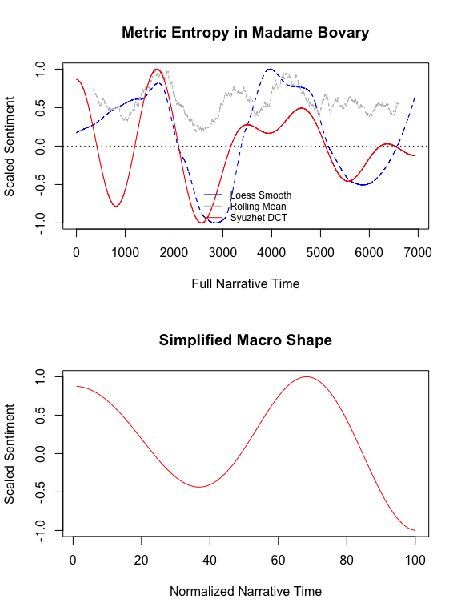

```r
simple_plot(out$metric_entropy,title = "Metric Entropy in Madame Bovary",legend_pos = "bottom")
```

This graph tells a slightly different story. It still shows the beginning of the novel to have high emotional entropy, but also identifies a second wave at around the 1800th sentence.

If we want to look at the specific sentences, it’s easy enough to sort them using `dplyr`. First we’ll examine a few sentences based on the highest entropy.

```r
library(dplyr)
sorted <- arrange(out, desc(entropy)) %>%
  select(entropy, sample_sents)
sorted[7:10, ]
```

```
##    entropy
## 7        1
## 8        1
## 9        1
## 10       1
##                                                                                                                                                                       sample_sents
## 7  Lively once, expansive and affectionate, in growing older she had become (after the fashion of wine that, exposed to air, turns to vinegar) ill-tempered, grumbling, irritable.
## 8                                                                                                                            When she had a child, it had to be sent out to nurse.
## 9                                                                                                           But, peaceable by nature, the lad answered only poorly to his notions.
## 10    His mother always kept him near her; she cut out cardboard for him, told him tales, entertained him with endless monologues full of melancholy gaiety and charming nonsense.
```

Here are a few that had high metric entropy.

```r
library(dplyr)
metric_sorted <- arrange(out, desc(metric_entropy)) %>%
  select(metric_entropy, sample_sents)
metric_sorted[4:7,]
```

```
##   metric_entropy              sample_sents
## 4           0.25       my poor, dear lady!
## 5           0.25 This work irritated Leon.
## 6           0.25      I adore pale women!"
## 7           0.25      The food choked her.
```